# Chap_2_ggplot

Elvira Lucas

2023-02-17

# Les graphiques avec ggplot

Pour ce chapitre nous allons utiliser le jeu de données `mpg`

```r
mpg <- transform(mpg, cyl = factor(cyl), trans = factor(trans), drv = factor(drv), fl = factor(fl), class = factor(class))
levels(mpg$trans) <- c(rep("auto", 8), rep("manual", 2))
```

## Les bases de ggplot

ggplot est un package mondialement utilisé pour la réalisation de graphiques plus complexes que ceux disponibles avec la fonction `plot` fourni de base dans R. La formation de graphiques avec ggplot est assez simple. Il s’agit de superposer différentes couches dans lesquelles on spécifie les caractéristiques du graphique.

Voici un exemple basique :

```r
ggplot(data   = mpg,              # spécifier les données
      mapping = aes(x = displ,    # mapper 'displ' à l'axe des x
                    y = hwy)) +   # mapper 'hwy' à l'axe des y
  geom_point()                    # tracer les points
```

Pour voir comment fonctionne le système de couches :

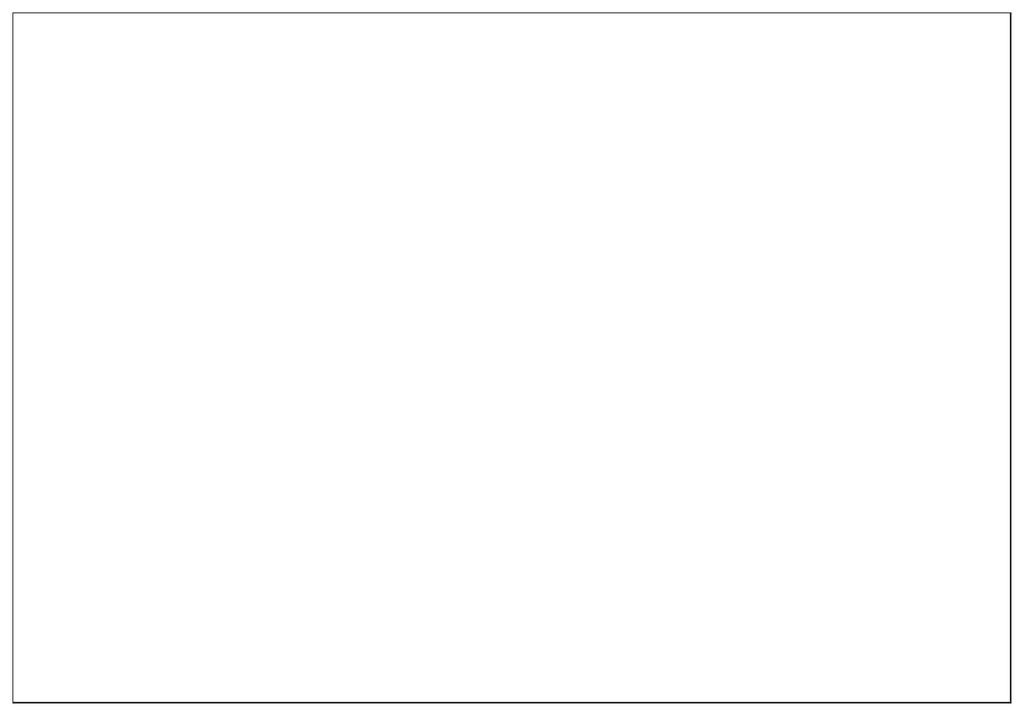

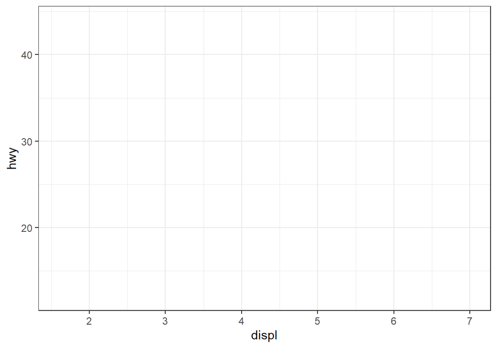

```r
ggplot(mpg)                                          # gauche
ggplot(mpg) + aes(x = displ, y = hwy)                # milieu
ggplot(mpg) + aes(x = displ, y = hwy) + geom_point() # droite
```

On peut sauvegarder un graphique

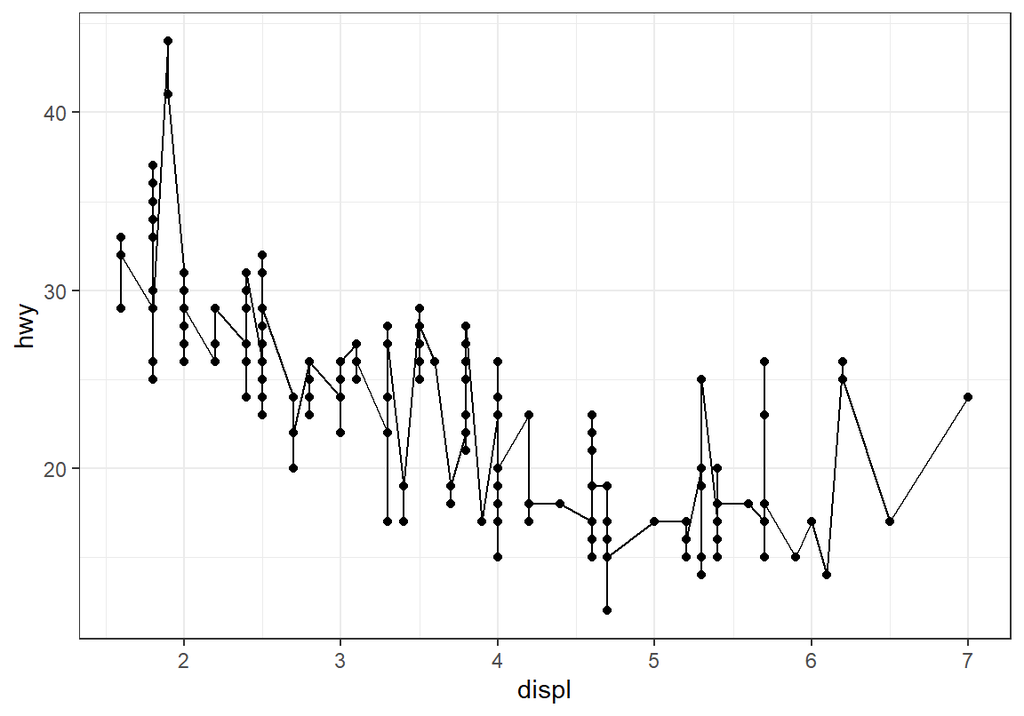

```r
p <- ggplot(mpg) +
      aes(x=displ, y= hwy) +
        geom_point()
p <- ggplot(mpg, aes(x = displ, y="")) +
      geom_point()

p + aes(y = hwy)                # gauche
p + aes(y = hwy) + geom_line()  # droite
```

Rajouter des informations sur les axes :

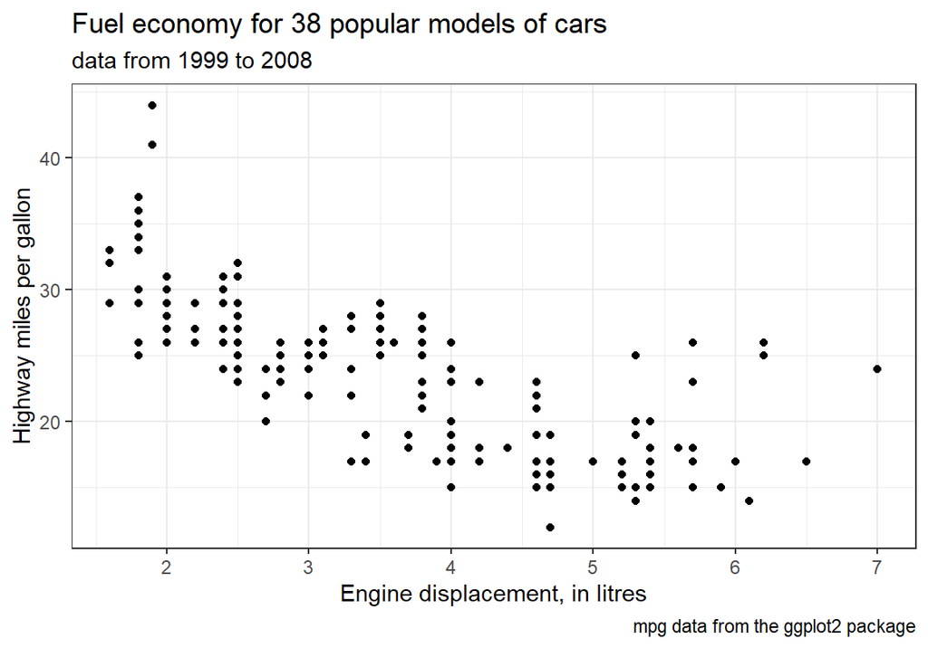

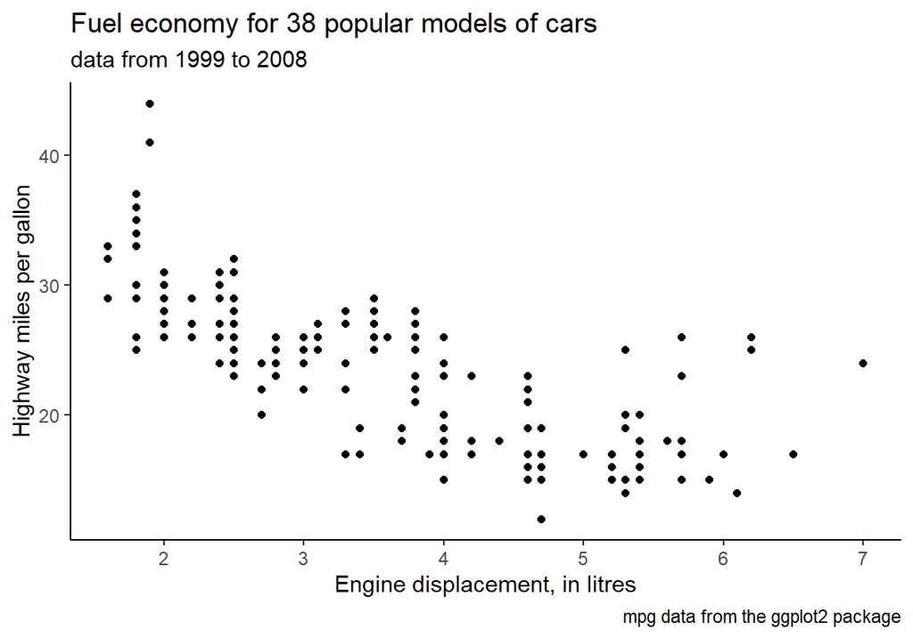

```r
p <- p + aes(y = hwy) +
  labs(
  title    = "Fuel economy for 38 popular models of cars",
  subtitle = "data from 1999 to 2008",
  x        = "Engine displacement, in litres",
  y        = "Highway miles per gallon",
  caption  = "mpg data from the ggplot2 package")
p + theme_bw()
p + theme_classic()
```

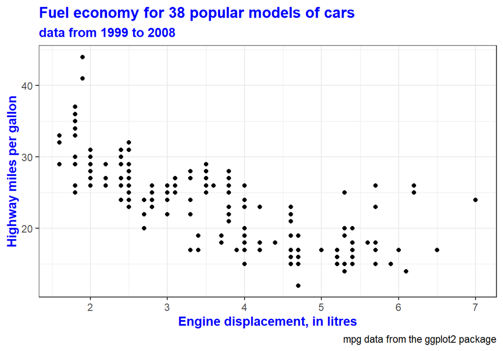

```r
p + theme_bw() + theme(
  axis.title = element_text(colour = "blue", face = "bold"),
  plot.title = element_text(colour = "blue", face = "bold"),
  plot.subtitle = element_text(colour = "blue", face = "bold"))
```

## Les propriétés esthétiques

Voici comment modifier l’esthétique de notre graphique :

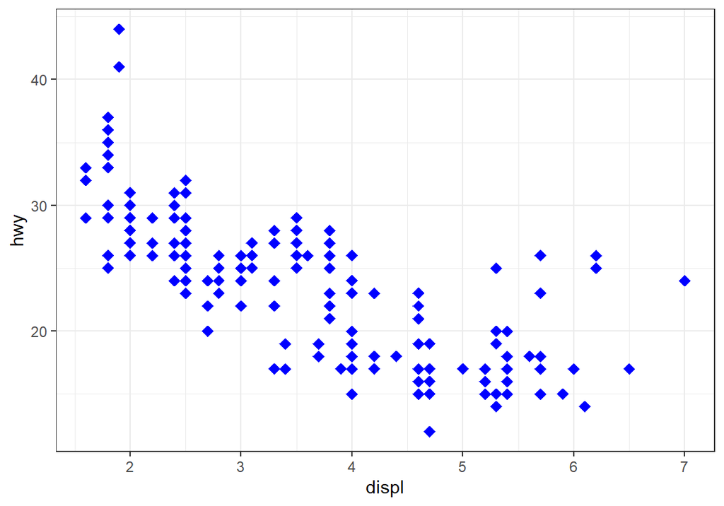

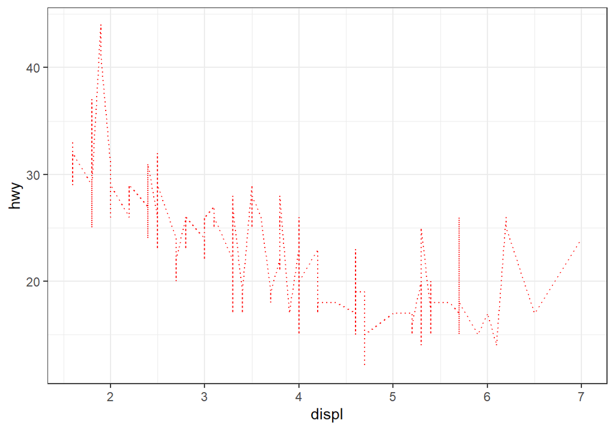

```r
ggplot(mpg, aes(x = displ, y = hwy)) + geom_point(shape = 18, size = 3, color = "blue")
ggplot(mpg, aes(x = displ, y = hwy)) + geom_line(color = "red", linetype = 3)
```

D’autres arguments disponibles sont `fill` pour la couleur de remplissage (barplot, histogramme,…) et `alpha` pour rajouter de la transparence (voir plus loin).

Les arguments esthétiques possèdent leur valeur par défaut (p.e `shape` = 19 pour `geom_point` et `linetype` = 1 pour `geom_line`).

Le contrôle sur les arguments esthétiques peut se faire à l’intérieur ou à l’extérieur de la fonction `aes()` suivant que l’on désire un changement “statique” ou “dynamique”. Si l’on souhaite garder la même couleur pour tous les points $\to$ dans la fonction `geom_<xxx>()`. Si l’on préfère avoir un changement de couleur des points suivant les valeurs d’une certaine variable dans le jeu de données $\to$ on utilisera plutôt la fonction `aes()`. Voici un exemple :

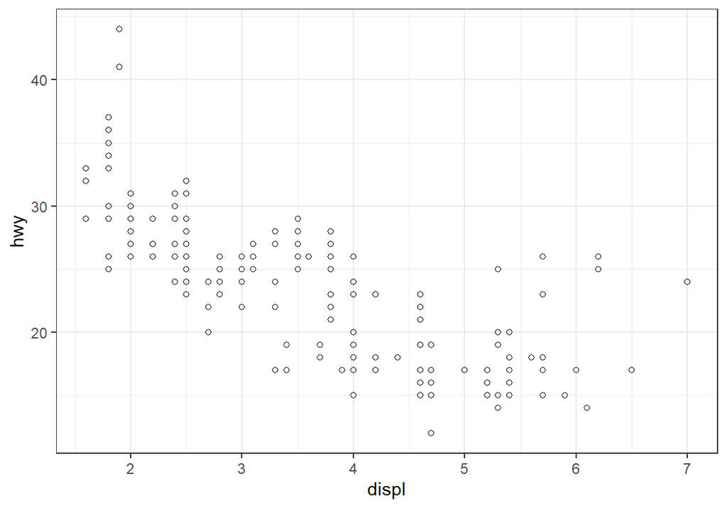

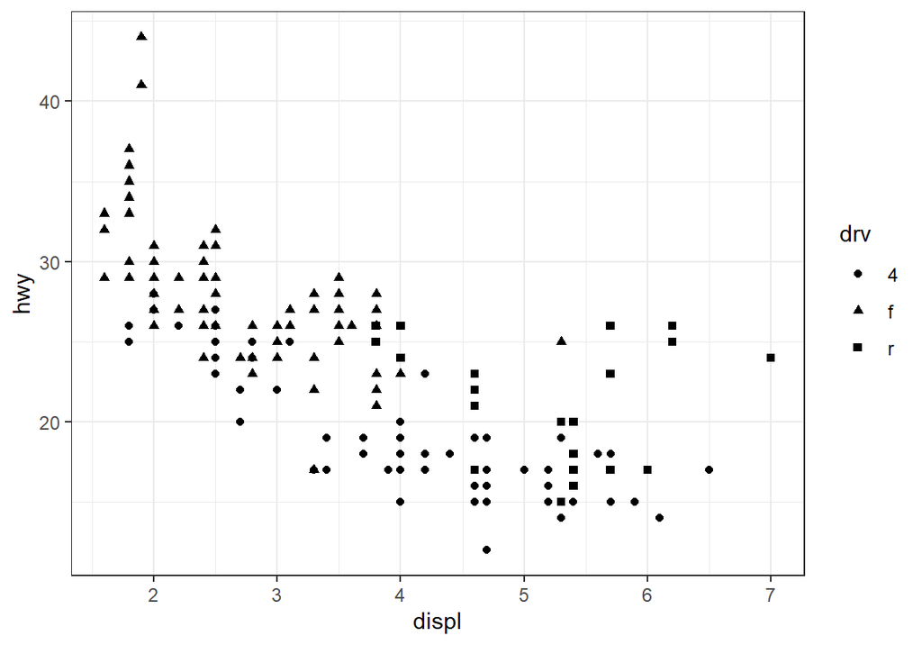

```r
# Forme identique pour tous
ggplot(mpg, aes(x = displ, y = hwy)) +
  geom_point(shape = 1)
# Forme change suivant la valeur de la variable drv
ggplot(mpg, aes(x = displ, y = hwy, shape = drv)) +
  geom_point()
```

Bien sûr on ne peut pas utiliser la variable dans `geom_point` comme utiliser un chiffre pour décrire la forme dans `aes` ne fonctionne pas.

Voici d’autres arguments esthétiques que l’on peut également modifier par le même principe.

- `color`

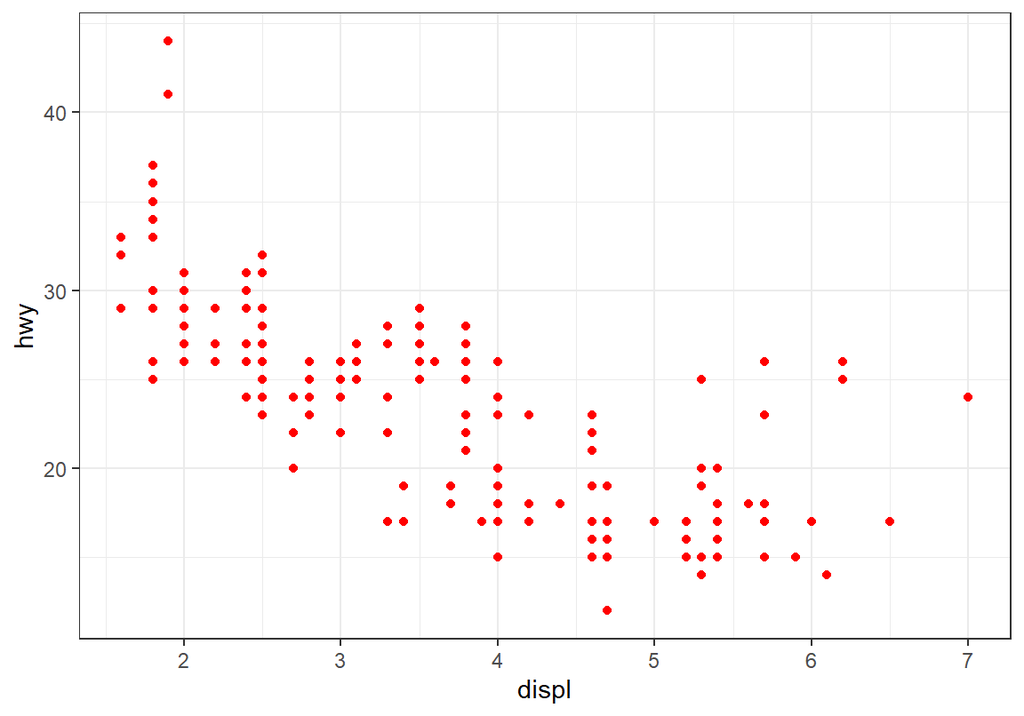

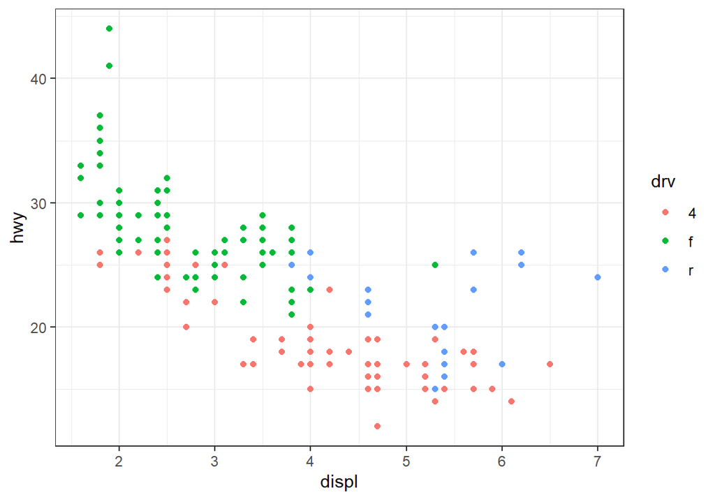

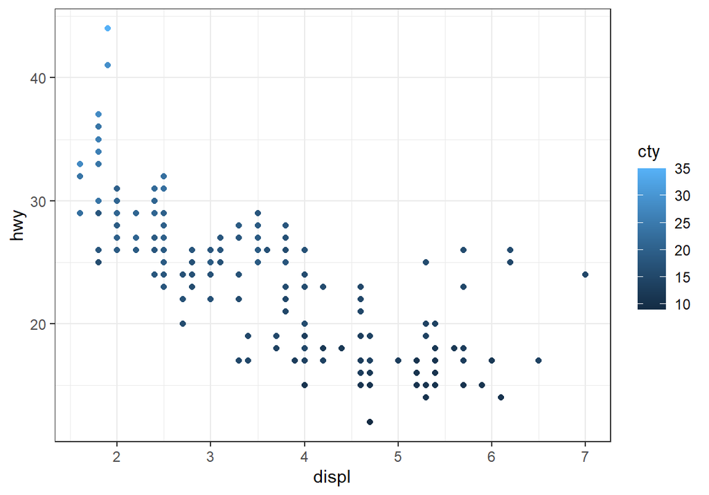

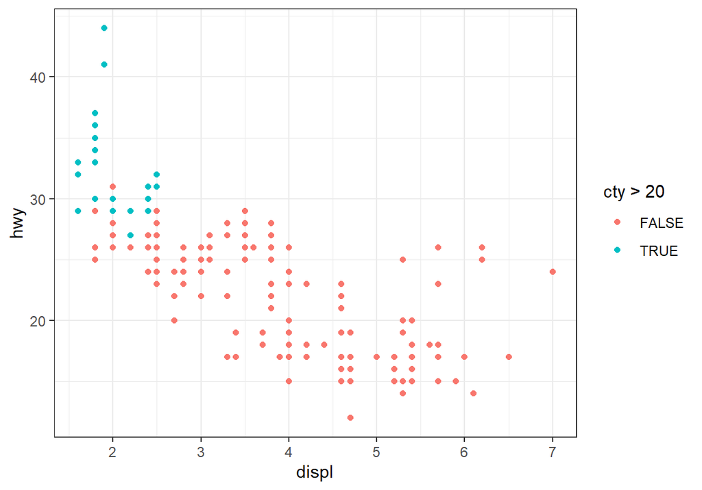

```r
p <- ggplot(mpg, aes(x = displ, y = hwy)) + geom_point()

# top
p + geom_point(color = "red")  # gauche : setting color
p + aes(color = drv)           # droite : mapping color with a factor
# bas
p + aes(color = cty)           # gauche : mapping color with a numeric
p + aes(color = cty > 20)      # droite : mapping color with a logical
```

En appelant la fonction `colours`, on peut avoir accès à toutes les couleurs standards de R

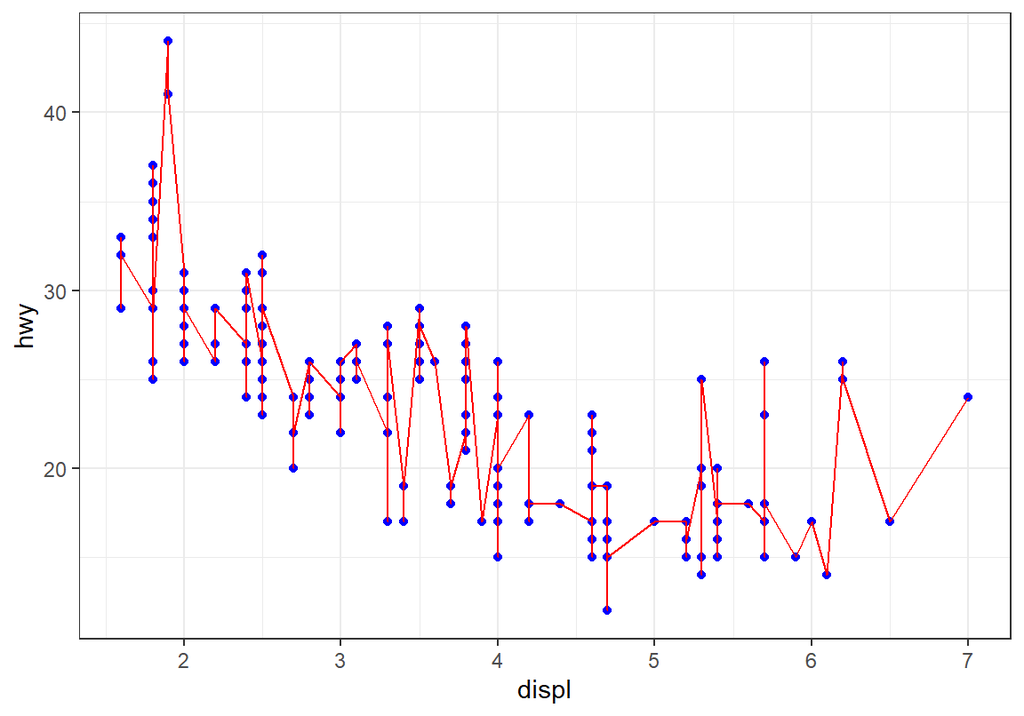

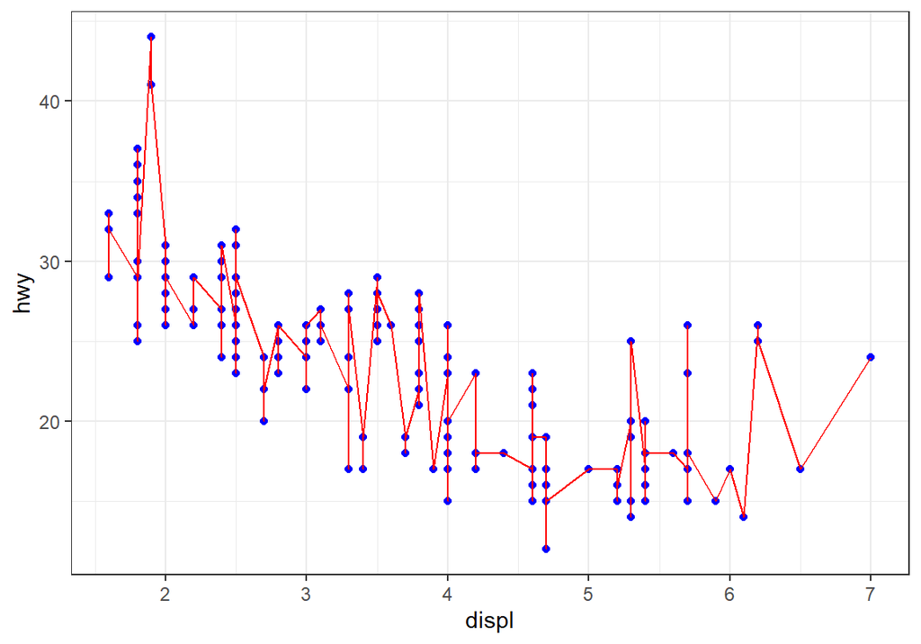

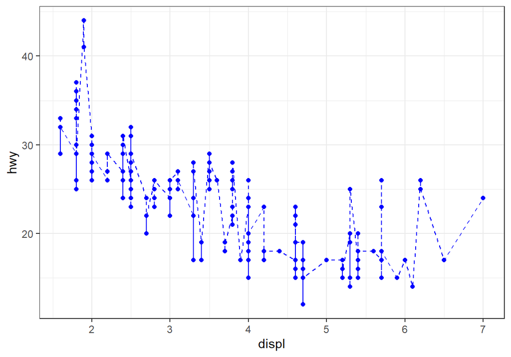

```r
ggplot(mpg, aes(x=displ, y=hwy)) +
  geom_point(col = "blue") + geom_line(col="red")

ggplot(mpg, aes(x=displ, y=hwy, col=I("blue"))) +
  geom_point() + geom_line(col="red")
# Rajouter le I() sinon ggplot pense que l'on utilise une variable prenant la valeur "blue" (oui il est un peu con)
ggplot(mpg, aes(x=displ, y=hwy, col=I("blue"))) +
  geom_point() + geom_line(linetype="dashed")
```

- `size`

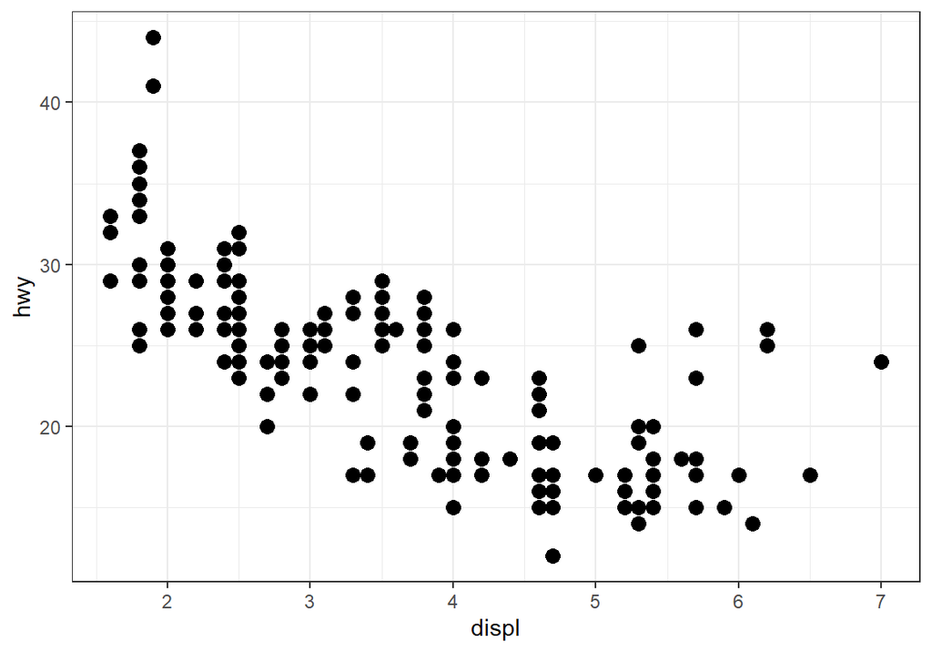

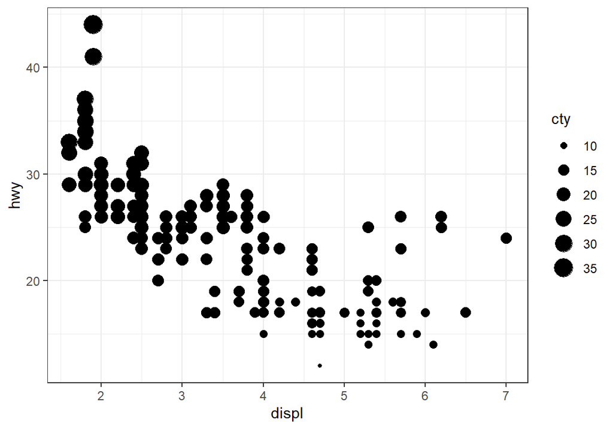

```r
p + geom_point(size = 3)   # gauche : setting size
p + aes(size = cty)        # droite : mapping size
```

- `linetype`

Ici on relie les points ne faisant partie que de la même catégorie.

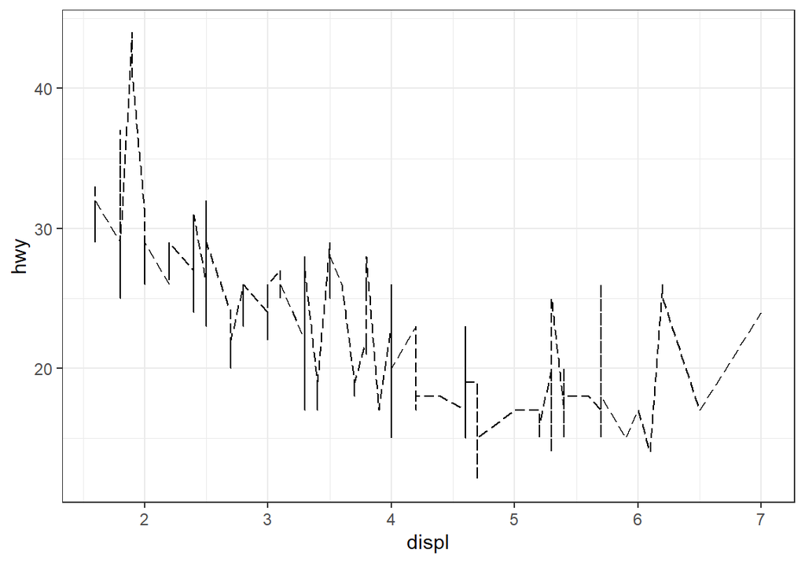

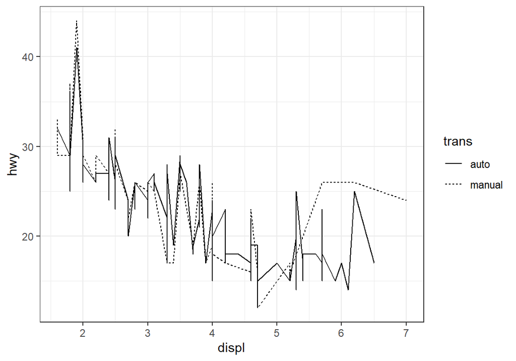

```r
# gauche : setting linetype
ggplot(mpg, aes(x = displ, y = hwy)) +
  geom_line(linetype = 5)
# droite : mapping linetype
ggplot(mpg, aes(x = displ, y = hwy, linetype = trans)) +
  geom_line()
```

- `alpha`

  Le alpha contrôle la transparence de remplissage prenant une valeur comprise entre 0 et 1 et permet de mieux visualiser les points lorque ceux-ci se chevauchent. Comme un exemple vaut toujours mieux qu’une explication :

```r
xtabs(~displ, data = mpg)
```

```
## displ
## 1.6 1.8 1.9   2 2.2 2.4 2.5 2.7 2.8   3 3.1 3.3 3.4 3.5 3.6 3.7 3.8 3.9   4 4.2
##   5  14   3  21   6  13  20   8  10   8   6   9   4   5   2   3   8   3  15   4
## 4.4 4.6 4.7   5 5.2 5.3 5.4 5.6 5.7 5.9   6 6.1 6.2 6.5   7
##   1  11  17   2   5   6   8   1   8   2   1   1   2   1   1
```

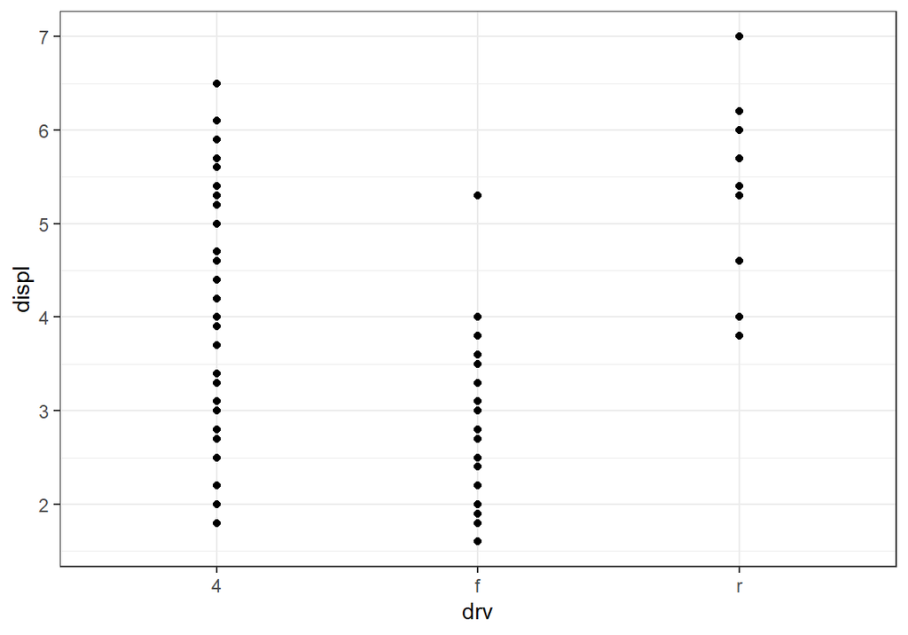

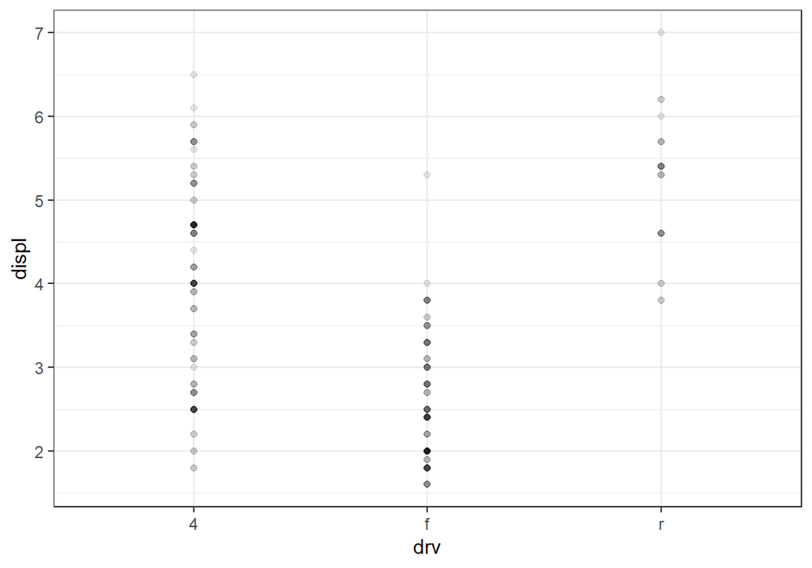

```r
# gauche
ggplot(mpg, aes(x = drv, y = displ)) +
  geom_point()
# droite
ggplot(mpg, aes(x = drv, y = displ)) +
  geom_point(alpha = 0.1)
```

Une autre solution plausible est d’utiliser la fonction `geom_jitter()` qui rajoute un décalage sur les points permettant de les visualiser.

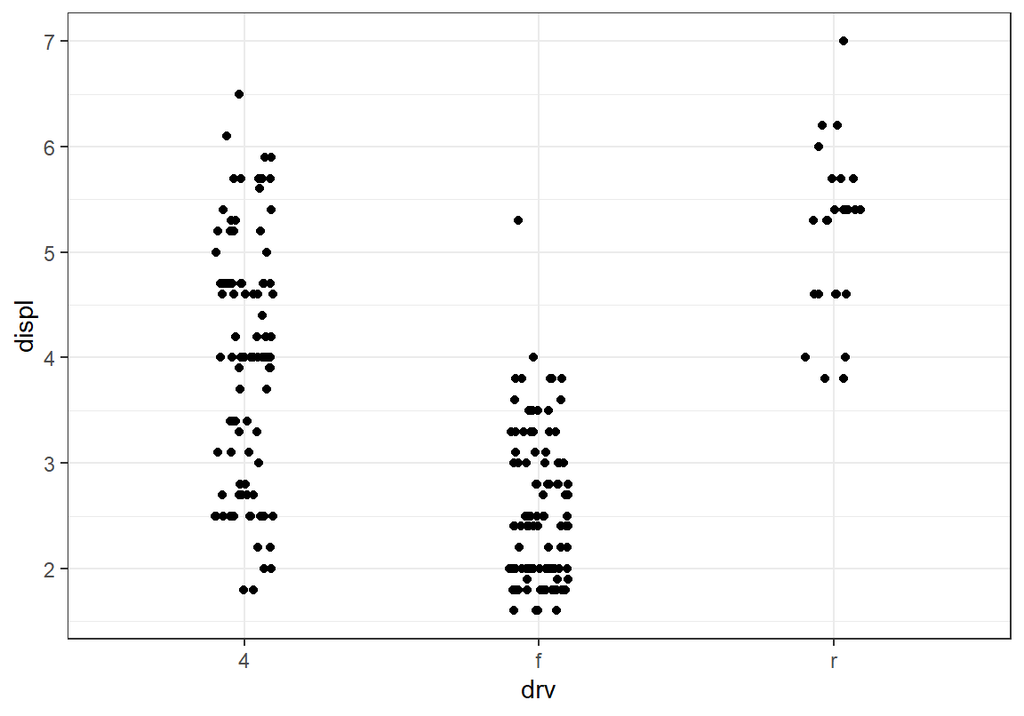

```r
ggplot(mpg, aes(x=drv, y=displ)) +
    geom_jitter(height = 0, width=.1)
```

Ici un exemple de graphique où l’on combine les arguments esthétiques. Attention que trop d’informations tue l’information.

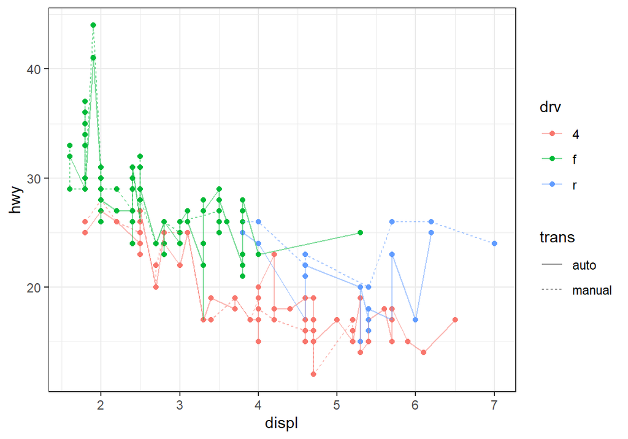

```r
ggplot(mpg, aes(x = displ, y = hwy, color = drv, linetype = trans)) +
  geom_point(size = 1.5) +
  geom_line(alpha = 0.5)
```

On peut également spécifier la fonction `aes()` dans les fonctions `geom_<xxx>()` au lieu de la spécifier dans la fonction `ggplot()`. La différence est que dans ce dernier, les arguments sont spécifiés pour **toutes** les fonctions du graphique, alors que dans le premier cas il n’est spécifié que pour la fonction utilisée. En voici un exmple (comparer le avec le précédent):

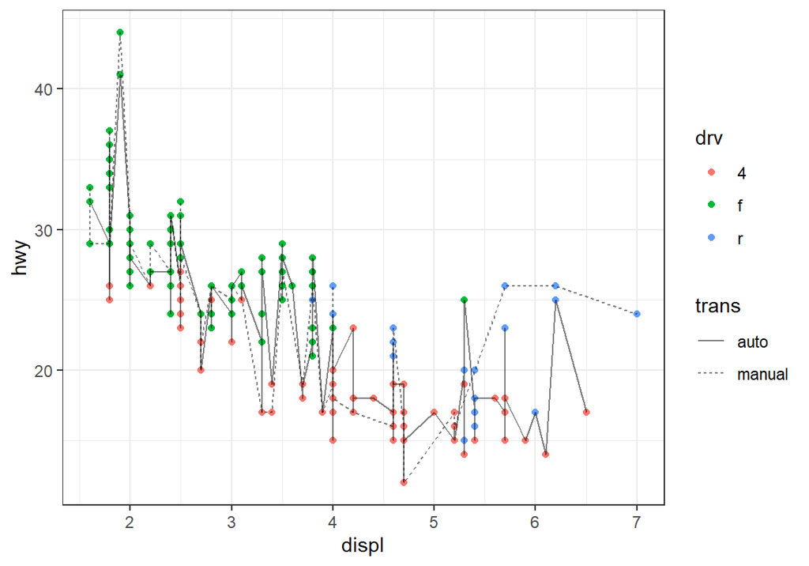

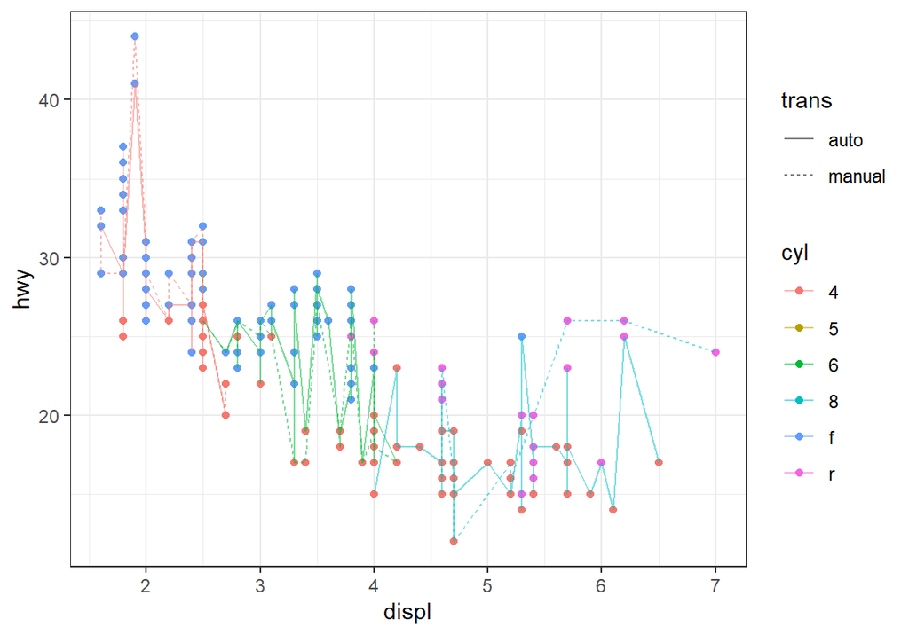

```r
ggplot(mpg, aes(x = displ, y = hwy)) +
  geom_point(aes(color = drv), size = 1.5) +
  geom_line(aes(linetype = trans), alpha = 0.5)

ggplot(mpg, aes(x = displ, y = hwy, color = cyl)) +
  geom_point(aes(col=drv), size = 1.5) +
  geom_line(aes(linetype = trans), alpha = 0.5)
#Jamais mettre deux aes(col) dans un même ggplot sinon il combine les deux et ça devient moche (ici on a les 4 valeurs de cyl + les 2 valeurs (f et r) de drv)
```

De la même façon, on peut également spécifier le jeu de données à utiliser dans la fonction globale comme dans les fonctions auxiliaires via l’argument `data`:

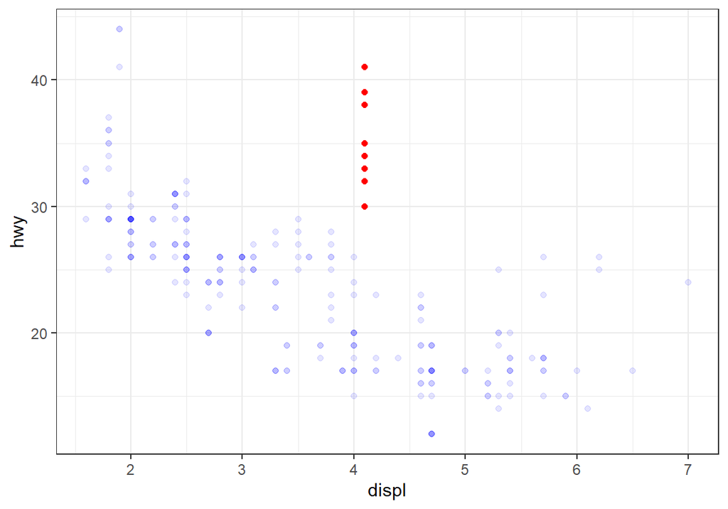

```r
# gauche
ggplot() +
  geom_point(data = mpg, mapping = aes(x = displ, y = hwy))
# droite
ggplot(mpg, aes(x = displ, y = hwy)) +
  geom_point(alpha = 0.1, color = "blue") +
  geom_point(data = subset(mpg, displ == 4), mapping = aes(x = displ + 0.1, y = hwy + 15), color = "red")
#data = est obligatoire si on veut utiliser un autre jeu de données
```

## Fonctions géométriques

Nous allons voir ici les différentes fonctions `geom_<xxx>()` disponibles.

- `geom_jitter()`

  Même chose que `geom_point()` sauf que l’on rajoute un bruit vertical et horizontal sur ceux-ci (bien sûr ce bruit ne permettra plus de bien spécifier les coordonnées du point).

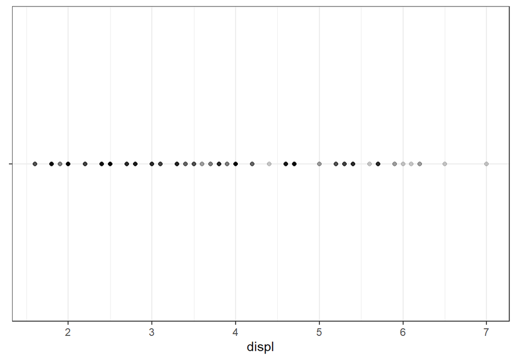

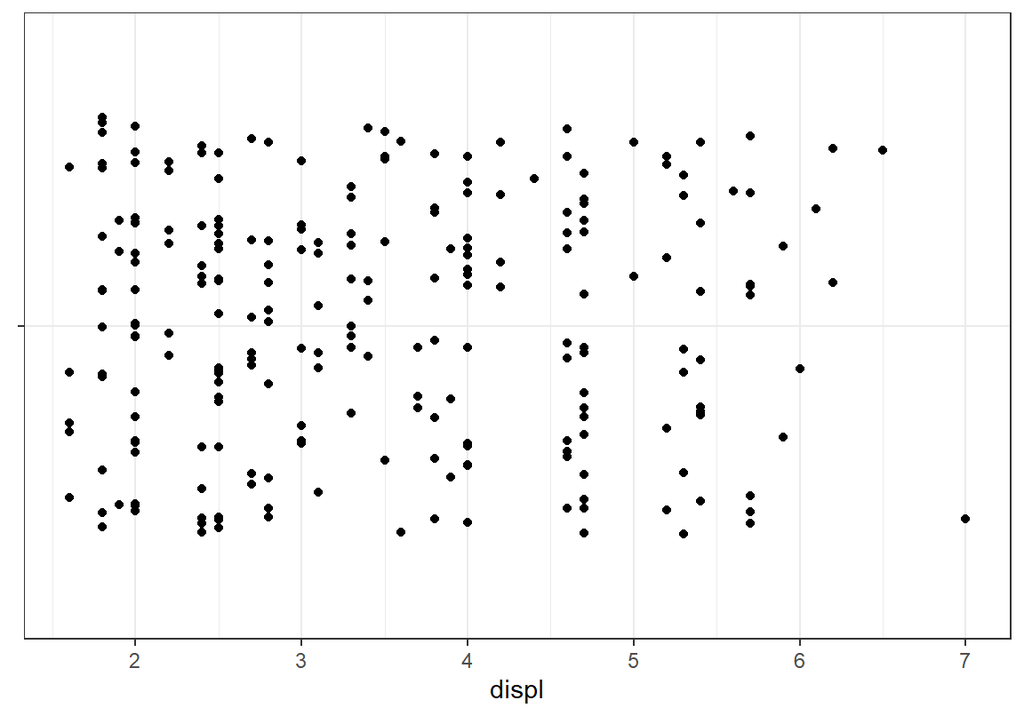

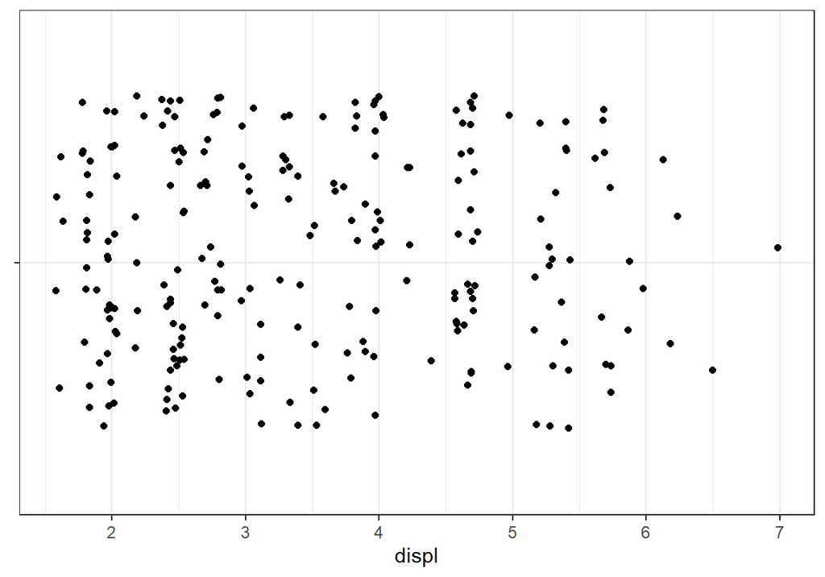

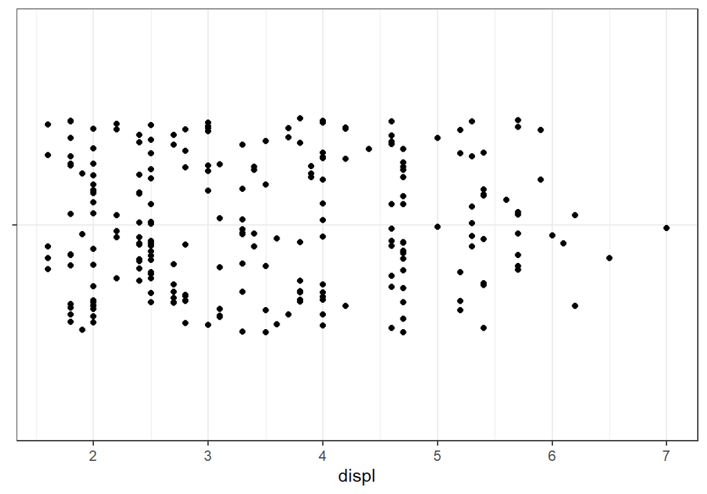

```r
p <- ggplot(mpg, aes(x = displ, y = "")) + labs(y = NULL)
p + geom_point(alpha=0.2)
p + geom_jitter(width=0) # On retire le bruit horizontal

# gauche : bruit horizontal et vertical
p +  geom_jitter()
# droite : bruit vertical uniquement
p + geom_jitter(width = 0, height = 0.3)
```

- `geom_boxplot()`